# İstatistiksel Analiz Uygulamaları Ara Sınav Ödevi

Ramazan Erduran, İlkay Şafak Baytar, Talha Kurt, Mert Hasan Kılıç, Müstecep Berca Akbayır

30 Aralık 2021

## Veri Manipülasyonu

**Tidyr Kütüphanesi(Düzenli Dağınık Veri):**

R’daki en önemli paketlerden biri tidyr paketidir. tidyr, ortak API’ler ve paylaşılan bir felsefe ile tasarlanmış bir paket ekosistemi olan tidyverse’nin bir parçasıdır. tidyr, reshape2 (2010-2014) ve reshape- (2005-2010) paketlerinin yerini almıştır.Tidyr, verilerinizi “düzenlemeyi” kolaylaştıran yani verilerimizi düzenli hale getirmemize yaran bir pakketir.Düzenli veriler, toplu evren boyunca mümkün olan her yerde kullanılan standart bir veri depolama yöntemini tanımlar. Düzenli verilerin en önemli iki özelliği şunlardır; Her sütun bir değişkendir, her satır bir gözlemdir,her hücre tek bir değerdir denebilir. Verilerinizi bu şekilde düzenlemek, değişkenlere (sütun adları olarak) ve gözlemlere (satır endeksleri olarak) atıfta bulunmak için tutarlı bir yolunuz olduğundan, Analiz yapmamız kolay bir hale gelir.

“tidyr”, “tidyverse” R paketleri koleksiyonun Düzenleme sağlayan “tibble” kütüphanesi gibi bir alt kütüphanesi olarak düşünülebilir.

Kurucu-Geliştirici-Destekçi : Hadley Wickham (Kurucu/Geliştirici-Tidyverse–RStudio)

R programının help menüsünden yararlanarak bu pakete baktığımızda ise; Her sütunun bir değişken, her satırın bir gözlem olduğu ve her hücrenin tek bir değer içerdiği düzenli veriler oluşturmaya yardımcı olacak araçlar. ‘tidyr’, bir veri kümesinin şeklini (pivoting) ve hiyerarşisini (yuvalama ve ‘yuvadan çıkarma’), derinlemesine iç içe geçmiş listeleri dikdörtgen veri çerçevelerine (‘dikdörtgenleme’) dönüştürmek ve dize sütunlarından değerleri çıkarmak için araçlar içerir. Ayrıca eksik değerlerle (hem örtük hem de açık) çalışmak için araçlar içerir yorumunu görmekteyiz.

**Kurulum**:

Bir paketi R programında kullanmak için önce paketin yüklenmesi gerekir. Tidyr paketinin yüklemesi aşağıdaki komut kullanılarak yapılabilir

**install.packages(“tidyr”)**

Daha sonra yukarıda bahsettiğimiz gibi Dağınık verileri düzenlemek için önce veri kümenizdeki değişkenleri tanımlarsınız, ardından bunları sütunlara taşımak için tidyr tarafından sağlanan araçları kullanırsınız.

**Tidyr işlevleri Beş Ana Kategoriye Ayrılır:**

-> Uzun ve geniş formlar arasında dönüşüm sağlar, bunu spread()ve gather() fonksiyonlarını kullanarak yapar. detyalı bilgi vermek gerekirse;

**gather() fonksiyonu**: Birden çok sütun alır ve bunları değer çiftlerinde toplar aslında; Geniş verileri daha uzun hale getirir. Bu işlev birden çok sütunu alır ve gerektiğinde diğer tüm sütunları çoğaltarak, anahtar-değer çiftleri içine atar.

**spread() fonksiyonu**: iki sütun (bir anahtar/değer çifti) alır ve bunları birden çok sütuna yayarak “uzun” verileri daha geniş hale getirir. Sütunlar yerine satırlar oluşturan değişkenleriniz olduğunda kullanılır.

Ayrıca spread()ve gather() fonksiyonları pivot_longer()ve pivot_wider() fonksiyonlarının yerini almıştır.

-> İç içe geçmiş listeleri düzenli tibble(data frame)’lara dönüştüren “Dikdörtgenleme”.bu işlemleri yaparken unnest_longer(), unnest_wider(), hoist() fonksiyonlarını kullanır.cDetaylı bilgi vermek gerekirse;

**unnest_longer() fonksiyonu**: Bir liste sütununun her öğesini bir satıra dönüştürür.

**unnest_wider() fonksiyonu**: Bir liste sütununun her öğesini bir sütuna dönüştürür.

**hoist() fonksiyonu**: Liste sütununun bileşenlerini seçerek kendi üst düzey sütunlarına çekmenize olanak tanır.

-> İç içe yerleştirme, gruplanmış verileri, her grubun iç içe geçmiş bir veri çerçevesi içeren tek bir satır haline geldiği bir forma dönüştürür ve verileri ayırmamızı sağlar. Bu işlemi yaparken nest(), unnest() fonksiyonlarını kullanır. Detaylı bilgi vermek gerekirse:

**nest() fonksiyonu**: Tüm iç içe değişkenleri içeren Data farme veri türnün bir listesini oluşturur. dolaylı olarak bir özetleme işlemidir. Bu, tüm veri kümeleriyle, özellikle de modellerle çalışan diğer özetlerle birlikte kullanışlıdır. Aslında nest() data frames şeklinden list-column’a dönüştürür.

**unnest() fonksiyonu**: Temel olarak nest() işlemini tersine çevirir. Listenin her elemanını kendi satırı yapar. Atomik vektörler, listeler veya data fream içeren (ancak farklı türlerin bir karışımını içermeyen) liste sütunlarını işleyebilir.

-> Karakter sütunlarını bölme ve birleştirme,birden çok sütunu tek bir karakter sütununda birleştirmek için ve tek bir karakter sütununu birden çok sütuna çekmek için separate(),extract() ve unite() fonksiyonlarını kullanır. Detaylı bilgi vermek gerekirse;

**separate() fonksiyonu**: Daha uzun verileri daha geniş bir biçime dönüştürür yani; Bir normal ifade veya bir karakterin konumlarının vektörü verildiğinde, separate(); tek bir karakter sütununu birden çok sütuna dönüştürür.

**extract() fonksiyonu**: Grupları yakalayan normal bir ifade verildiğinde, extract(), her grubu yeni bir sütuna dönüştürür. Gruplar eşleşmezse veya giriş NA ise, çıkış NA olur.

**unite() fonksiyonu**: İki sütunu bir sütunda birleştirir. Birden fazla değişken değerlerini yapıştırmak için bir kolaylık sağlayan bir fonksiyonudur. Kısaca tek bir gözlemin iki değişkenini tek bir değişkende birleştirir.

-> Örtük eksik değerleri açık hale getirir, örtük açık eksik değerler yapar ; eksik değerleri sonraki/önceki değerle veya bilinen bir değeri ile değiştirir. Bunlar için complete(), drop_na(), fill() ve replace_na() fonkiyonlarını kullanır. Detaylı bilgi vermek gerekirse;

**complete() fonksiyonu**: Örtülü eksik değerleri açık eksik değerlere dönüştürür.

**drop_na() fonksiyonu**: Eksik değerleri içeren satırları veriden çıkartır.

**fill() fonksiyonu**: seçili sütunlardaki eksik değerleri doldurur. Bu, değerlerin tekrarlanmadığı ve yalnızca değiştiklerindekaydedilir.kaydedilen çıktı ise ortak çıktı biçiminde kullanışlı olur.

**replace_na() fonksiyonu**: Eksik değerlerin içine atama yapmak için kullanılır.

tidyr, dağınık verilerinizi düzenlemek için üç ana işlev sunar: gather(), separate()ve spread(). Bu fonksiyonlar ve yukarıda bahsedilen fonksiyonlar haricinde diğer fonksiyonlar ağağıda açıklanmıştır.

**pivot_longer() fonskiyonu**: pivot_longer(), satır sayısını artırarak ve sütun sayısını azaltarak verileri uzatır.

**pivot_wider() fonksiyonu**: pivot_wider(), satır sayısını azaltarak ve sütun sayısını artırarak verileri kısaltır.

**starts_with()fonksiyonu**: “Bu seçimin yardımcıları, değişkenleri belirli bir desene göre eşleştirir. Bu yardımcılar ise adlarındaki kalıpları eşleştirerek değişkenleri seçer:

1-starts_with(): Baş kısmına eklerin .

2-ends_with(): Sonuna ekler.

3-contains(): Gerçek bir dize içerir.

4-matches(): Normal bir ifadeyle eşleşir.

5-num_range(): x01, x02, x03 gibi sayısal bir aralıkla eşleşir.

**crossing()fonksiyonu**: Girdilerini tekilleştiren ve sıralayan expand_grid() çevresinde bir sarmalayıcıdır.

**all_of()fonksiyonu**: Bir karakter vektöründeki değişken adlarını eşleştirir. Tüm adlar mevcut olmalıdır, aksi takdirde bir sınır dışı hatası verilir.

**any_of()fonksiyonu**: all_of() İle aynı, ancak var olmayan adlar için hiçbir hata atılmaz.

**full_seq() fonksiyonu**: Temel olarak bir vektörde gözlemlenmesi gereken ancak gözlemlenmeyen eksik değerleri doldurur. Önemli bir nokta Vektör sayısal olmalıdır.

Ek olarak tidyr’de düzenli değerlendirmenin iki temel biçimi kullanılır:

**Tıdy Selection:**

**Data Masking:**

Veri değişkenlerini ortamdaki değişkenlermiş gibi kullanmamıza izin verir. Bu işlevi; as_tibble(), nesting(), crossing(), expand() fonksiyonlarını kullanarak gerçekleştirir.

Yukarıda verdiğimiz bilgileri kısaca özetlemek gerekirse, tidyr verileri düzenlemeye, temizlememizi ve manipüle etmemizi kolaylaştıran ve buna olanak sağlayan bir kütüphanedir.

Yukarıda da bahsettiğmiz gibi tidyr, dağınık verilerinizi düzenlemek için üç ana işlev sunar: gather(), separate()ve spread() bu fonksiyonları verilerimizle örneklemek gerekirse;

**gather() fonsiyonu örneği:**

```r
library(tidyr)
library(readr)
corona <- read_csv("C:/Users/lenovo/Documents/GitHub/R-Final/Datasets/coronavirus.csv")
head(corona, 3) #kitlemiz
```

```
## # A tibble: 3 x 67
##   iso_code continent location  date       total_cases new_cases new_cases_smoot~
##   <chr>    <chr>     <chr>     <date>           <dbl>     <dbl>            <dbl>
## 1 AFG      Asia      Afghanis~ 2020-02-24           5         5               NA
## 2 AFG      Asia      Afghanis~ 2020-02-25           5         0               NA
## 3 AFG      Asia      Afghanis~ 2020-02-26           5         0               NA
## # ... with 60 more variables: total_deaths <dbl>, new_deaths <dbl>,
## #   new_deaths_smoothed <dbl>, total_cases_per_million <dbl>,
## #   new_cases_per_million <dbl>, new_cases_smoothed_per_million <dbl>,
## #   total_deaths_per_million <dbl>, new_deaths_per_million <dbl>,
## #   new_deaths_smoothed_per_million <dbl>, reproduction_rate <dbl>,
## #   icu_patients <dbl>, icu_patients_per_million <dbl>, hosp_patients <dbl>,
## #   hosp_patients_per_million <dbl>, weekly_icu_admissions <dbl>, ...
```

```r
set.seed(10) #kodu her çalıştırdığımızda örneklemimizin değişmemesi için kullandığımız bir fonksiyon
data_sample <- corona[sample(nrow(corona),10),replace=F]
class(data_sample)
```

```
## [1] "tbl_df"     "tbl"        "data.frame"
```

```r
sutun <- c("x", "y")
new<-data.frame(sutun,data_sample$new_deaths,data_sample$total_cases_per_million,data_sample$total_cases)
new_new<- gather(new, referans, yeni_deger, -sutun)
print(new_new)
```

```
##    sutun                            referans   yeni_deger
## 1      x              data_sample.new_deaths       18.000
## 2      y              data_sample.new_deaths        0.000
## 3      x              data_sample.new_deaths        0.000
## 4      y              data_sample.new_deaths           NA
## 5      x              data_sample.new_deaths        0.000
## 6      y              data_sample.new_deaths    15271.000
## 7      x              data_sample.new_deaths           NA
## 8      y              data_sample.new_deaths       13.000
## 9      x              data_sample.new_deaths        2.000
## 10     y              data_sample.new_deaths           NA
## 11     x data_sample.total_cases_per_million       81.673
## 12     y data_sample.total_cases_per_million        5.456
## 13     x data_sample.total_cases_per_million     1534.298
## 14     y data_sample.total_cases_per_million        8.602
```

[output cut: 16 more lines]

Bu kod bloğunda görüldüğü gibi kümme verilerimiz çok büyük olduğu için **set.seed** foknsiyonu ile her sütün için 10 gözleme indirerek devam ettik, verimizi data fream formatına dönüştürdük ve gather() fonksiyonu ile 3 sütunu birleştirerek tek bir sütun haline getirdik.

```r
library(tidyr)
class(data_sample)
```

```
## [1] "tbl_df"     "tbl"        "data.frame"
```

```r
sutun <- c("x", "y")
yeni<-data.frame(sutun,data_sample$location,data_sample$total_cases_per_million,data_sample$date)
yeni_yeni <- separate(yeni, data_sample.date, c("yil", "ay","gün"))
print(yeni_yeni)
```

```
##    sutun      data_sample.location data_sample.total_cases_per_million  yil ay
## 1      x                    Russia                              81.673 2020 04
## 2      y                   Myanmar                               5.456 2020 06
## 3      x                Madagascar                            1534.298 2021 10
## 4      y      Micronesia (country)                               8.602 2021 08
## 5      x                    Rwanda                             458.253 2020 12
## 6      y                     World                           11329.646 2021 01
## 7      x      Micronesia (country)                               8.602 2021 09
## 8      y                   Armenia                            7832.209 2020 06
## 9      x                     Haiti                            1293.659 2021 06
## 10     y Saint Pierre and Miquelon                            5544.966 2021 10
##    gün
## 1   10
## 2   28
## 3   15
## 4   18
## 5   05
## 6   08
## 7   09
## 8   26
## 9   03
## 10  13
```

Bu kod bloğunda görüldüğü gibi tekrar “yeni” adında bir veri seti oluşturduk çünkü diğer örneklerde oluşturduğumuz veri setleri bu örnek için kullanılamaz. Bu örnekte separate() fonksiyonunu kullanarak yeni adlı veri setimizdeki date sütununu yıl, ay ve gün sütunu şeklinde 3 sütuna ayırdık.

**Verimizi Manipüle Etme ve Düzenleme Aşaması:**

```r
library(readr)
library(dplyr)
library(tidyr)
corona <- read_csv("C:/Users/lenovo/Documents/GitHub/R-Final/Datasets/coronavirus.csv")
head(corona)
```

```
## # A tibble: 6 x 67
##   iso_code continent location  date       total_cases new_cases new_cases_smoot~
##   <chr>    <chr>     <chr>     <date>           <dbl>     <dbl>            <dbl>
## 1 AFG      Asia      Afghanis~ 2020-02-24           5         5           NA
## 2 AFG      Asia      Afghanis~ 2020-02-25           5         0           NA
## 3 AFG      Asia      Afghanis~ 2020-02-26           5         0           NA
## 4 AFG      Asia      Afghanis~ 2020-02-27           5         0           NA
## 5 AFG      Asia      Afghanis~ 2020-02-28           5         0           NA
## 6 AFG      Asia      Afghanis~ 2020-02-29           5         0            0.714
## # ... with 60 more variables: total_deaths <dbl>, new_deaths <dbl>,
## #   new_deaths_smoothed <dbl>, total_cases_per_million <dbl>,
## #   new_cases_per_million <dbl>, new_cases_smoothed_per_million <dbl>,
## #   total_deaths_per_million <dbl>, new_deaths_per_million <dbl>,
## #   new_deaths_smoothed_per_million <dbl>, reproduction_rate <dbl>,
## #   icu_patients <dbl>, icu_patients_per_million <dbl>, hosp_patients <dbl>,
## #   hosp_patients_per_million <dbl>, weekly_icu_admissions <dbl>, ...
```

*Buradaki kod satırında;; “corona” adlı veri setimizi R’a aktarma işlemini yaptık, kullnacağımız kütüphanelerin girişlerini yaptık.*

```r
library(readr)
library(dplyr)
library(tidyr)
a <-corona %>%
  filter(continent %in% c("Africa","Asia","Europe","North America","South America")) %>%
  summarize(date=date,continent=continent, location=location, new_cases=new_cases, total_cases=total_cases, new_cases_per_million=new_cases_per_million,
            new_deaths=new_deaths, total_deaths=total_deaths, new_deaths_per_million=new_deaths_per_million, population=population,cases_density_population=total_cases/population)
```

*Buradaki kod satırında;; Corona verisinin içine girmemize yardımcı olan fonksiyon (%>%) ile yeni bir data seti oluşturmak üzere Corona verisinde yapılacak işlemleri a data setinin içine aktardık. “filter” fonksiyonunu kullanarak Corona verisinin içindeki Africa, Asia, Europe, North America ve South America kıtalarını a datasına atanmasını sağladık daha sonra, Verimizde kullanmak istediğimiz sütunlaru summarize() fonksiyonunu kullanarak çektik.*

```r
a <- a%>%
  filter(date > "2020-06-01" & date <"2020-06-30") %>%
  drop_na()
```

*Buradaki kod satırında;; Veri setimizdeki tarih verilerini filter() fonksiyonunu kullanarak “2020-06-01” ile “2020-06-30” tarihi arasındaki veriler olarak filtreledik ve drop_na() fonksiyonun kullanarak eksik ve na değerlerini içeren kod satırlarını verimizden çıkardık.*

```r
library(dplyr)
africa <- a %>%
  filter(continent == "Africa")
Asia <- a %>%
  filter(continent == "Asia")
Europe <- a %>%
  filter(continent == "Europe")
North_America <- a %>%
  filter(continent == "North America")
South_America <- a %>%
  filter(continent == "South America")
```

*Buradaki kod satırında; “a” veri setine atadığımız kıtaları filter() fonksiyonunu kullanarak her kıta için ayrı olarak oluşturduğumuz veri setinin içine atayarak filtreleme yaptık.*

```r
x_asia <- Asia[sample(nrow(Asia),20),]
x_africa <- africa[sample(nrow(africa),20),]
x_europe <- Europe[sample(nrow(Europe),20),]
x_sth_america <- South_America[sample(nrow(South_America),20),]
x_nrth_america <- North_America[sample(nrow(North_America),20),]
```

*Buradaki kod satırında; Kıtalara ait veri setlerimizi oluşturduktan sonra anlaşılabilir hale getirmek için bu veri setlerinin satırlarını 20 satıra indirgeyerek veri düzenlemesi işlemine devam ettik.*

```r
x_corona <- rbind(x_asia,x_africa,x_europe,x_sth_america,x_nrth_america)
```

*Buradaki kod satırında;Veri setlerini 20 satıra indirdikten sonra hepsini tek bir veri setinde toplamak için rbind() fonksiyonunu kullanarak “x_corona” data sına atama işlemini gerçekleştirdik.*

```r
y_corona <- x_corona[,-1]
```

*Buradaki kod satırında; 1. sütünda bulunana tarih verilerini veri setimizden çıkardık.*  
**Bu işlemler sonucunda, Gozlemi yapilacak veri “y_corona” verisi olarak elde edilmiştir.**

## Veri Görselleştirme

```r
library(esquisse)
```

*Esquisse paketi, verilerimizi etkileşimli olarak keşfetmenize ve görselleştirmenize yardımcı olan bir pakettir. Değişkenlerimizi sürükle ve bırak ile etkileşimli olarak ggplot grafikleri oluşturmamızı sağlar. Görselimizi ‘PNG’ veya ’PowerPoint’e aktarabilir veya scriptimize eklemek için kodu içeriye aktarabiliriz.*

```r
y_corona$continent <- as.factor(y_corona$continent)
y_corona$location <- as.factor(y_corona$location)
```

*as.factor() kodunu kullanarak kıta ve ülke değişkenlerimizi faktör haline getirdik ki esquisse’de grafik çizdirirken kütüphanenin daha doğru tepki vermesini sağlayabilelim.*

```r
#esquisser(data=y_corona)
```

*yorum satırına aldığımız esquisser() komutu, sürükle bırak şeklinde grafik çizdirebileceğimiz pencereryi açmamıza olanak sağlıyor.*

#### Bar Grafikleri

**TÜM KITALARA İLİŞKİN BAR GRAFİĞİ**

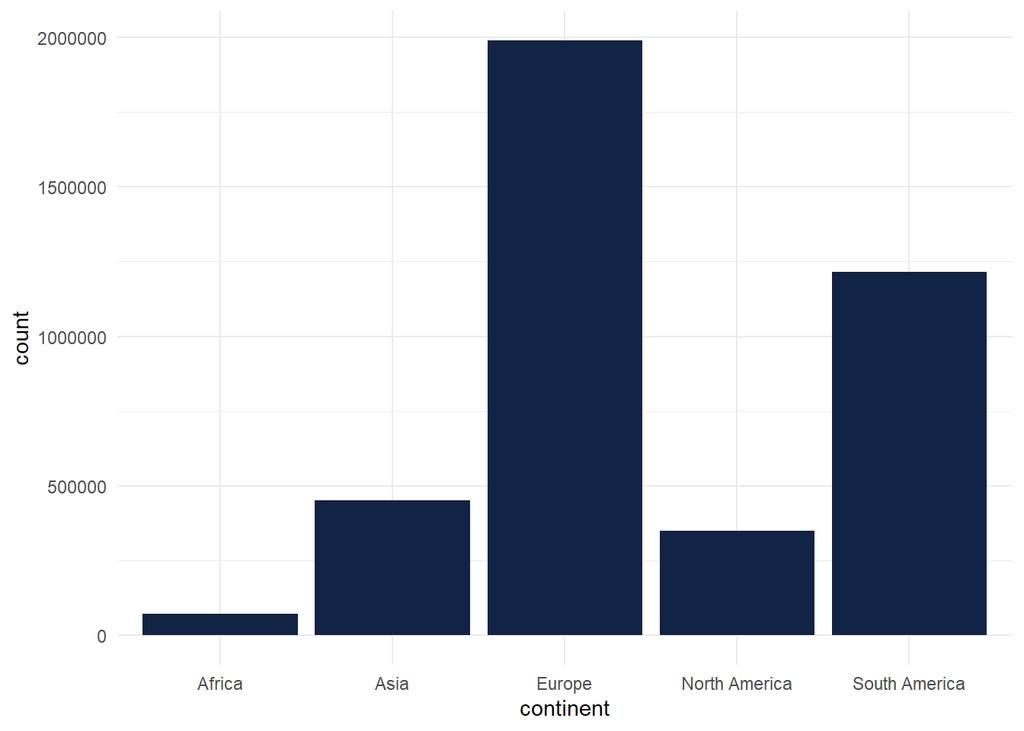

```r
library(ggplot2)
ggplot(y_corona) +
 aes(x = continent, weight = total_cases) +
 geom_bar(fill = "#112446") +
 theme_minimal()
```

*Bu grafiğe bakarak, söylenebilir ki en fazla veri Avrupa’da gözlenmiş. Bunun yanında ise gözlenmiş en az değerler Afrika ya ait olmuş.*

**Asya’nın günlere göre yeni vaka sayısının bar grafiği:**

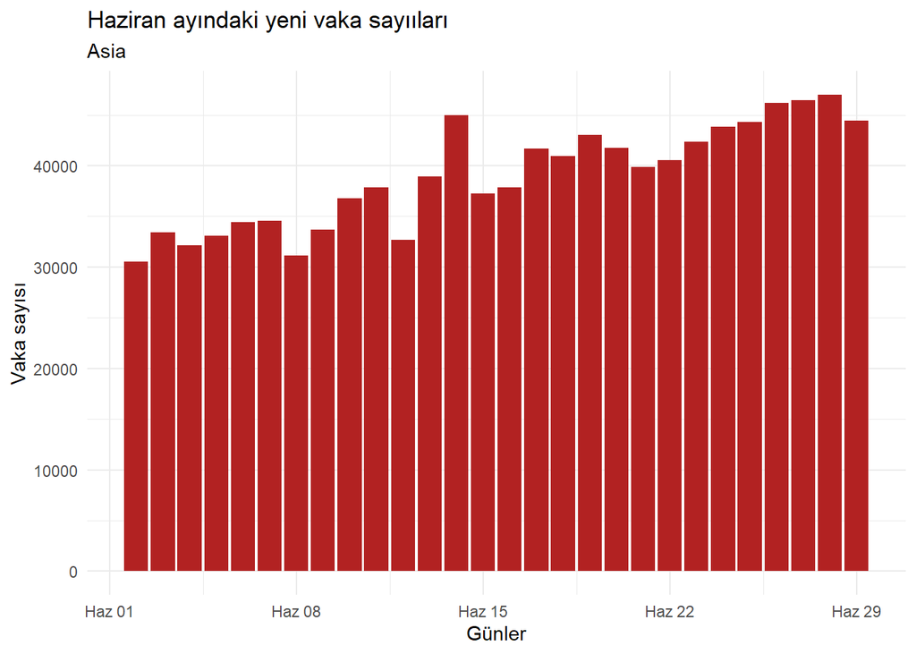

```r
library(ggplot2)
ggplot(Asia) +
 aes(x = date, weight = new_cases) +
 geom_bar(fill = "#B22222") +
 labs(x = "Günler", y = "Vaka sayısı",
 title = "Haziran ayındaki yeni vaka sayııları", subtitle = "Asia") +
 theme_minimal()
```

*Bu bar grafiğimizde ise gün geçtikçe yeni vaka sayısının arttığını da çok net bir şekilde söyleyebiliriz. Ayrıca Haziran ayına ait olan bu verilerde vaka sayısı günlük en az 30.000’i görmüştür.*

**Avrupa’nın günlere göre yeni vaka sayısının bar grafiği:**

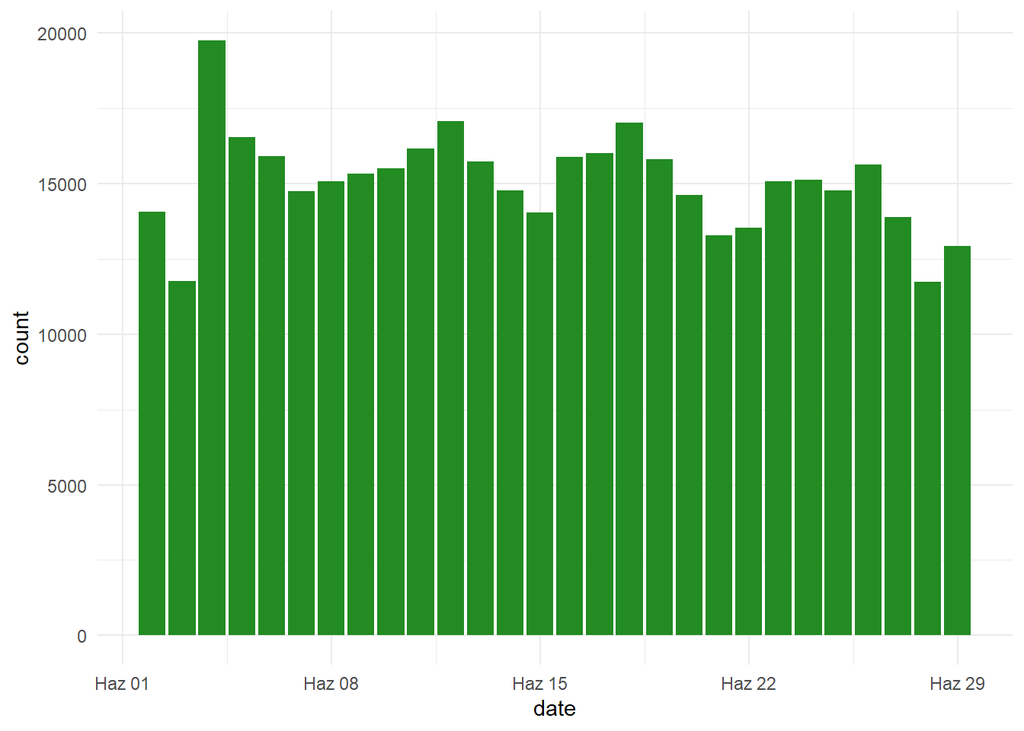

```r
library(ggplot2)
ggplot(Europe) +
 aes(x = date, weight = new_cases) +
 geom_bar(fill = "#228B22") +
 theme_minimal()
```

*Avrupaya ait olan grafikte Net bir şekilde yeni vaka sayıları gittikçe azalıyor diyemesek de söyleyebiliriz ki ayın başlarında görülen yüksek sayıdaki vaka sayıları haziran ayı sonlarına doğru biraz daha azalmıştır.*

**Kuzey Amerika’nın günlere göre yeni vaka sayısının bar grafiği:**

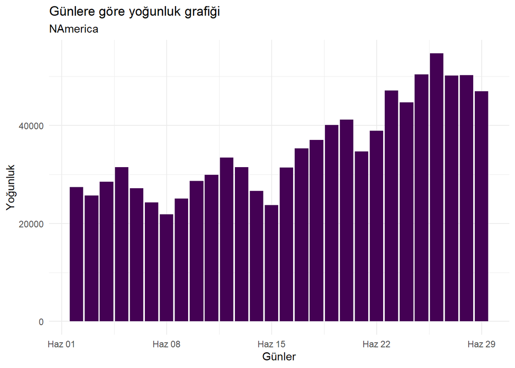

```r
library(ggplot2)
ggplot(North_America) +
 aes(x = date, weight = new_cases) +
 geom_bar(fill = "#440154") +
 labs(x = "Günler",
 y = "Yoğunluk", title = "Günlere göre yoğunluk grafiği", subtitle = "NAmerica") +
 theme_minimal()
```

*Kuzey Amerika’ya ait bu grafikte çok net bir şekilde söyleyebiliriz ki gün geçtikçe vaka sayıları artmıştır. Demek ki rehavete kapılmamak gerekirmiş.*

**Güney Amerika’nın günlere göre yeni vaka sayısının bar grafiği:**

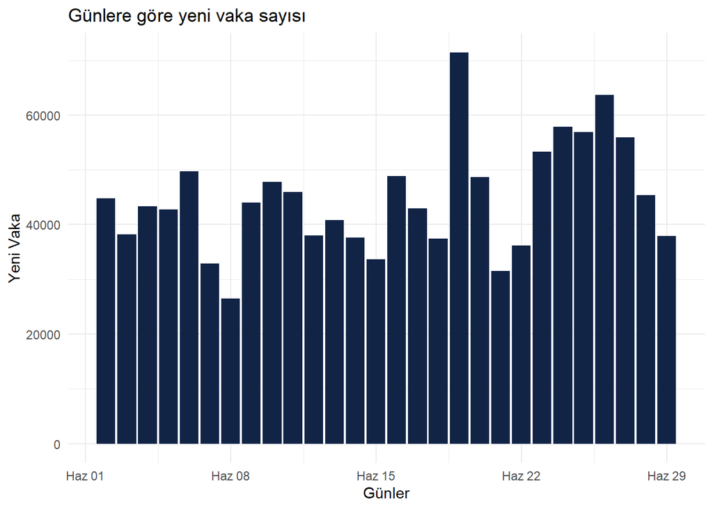

```r
library(ggplot2)
ggplot(South_America) +
 aes(x = date, weight = new_cases) +
 geom_bar(position = "dodge", fill = "#112446") +
 labs(x = "Günler", y = "Yeni Vaka", title = "Günlere göre yeni vaka sayısı") +
 theme_minimal()
```

**Afrika’nın günlere göre yeni vaka sayısının bar grafiği:**

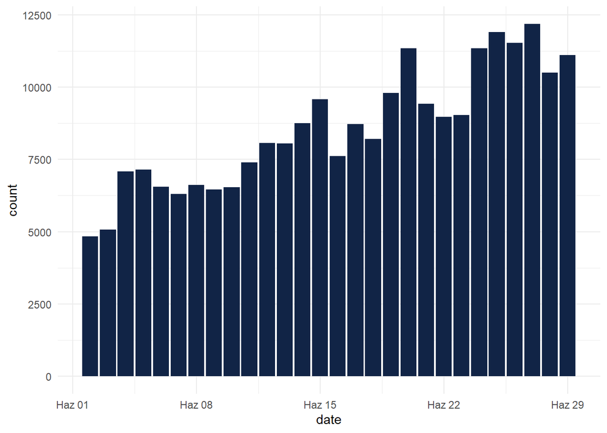

```r
library(ggplot2)
ggplot(africa) +
 aes(x = date, weight = new_cases) +
 geom_bar(fill = "#112446") +
 theme_minimal()
```

*Afrikaya ait grafiğe 1 belki 1.5 sn bakmamız yeterli olacaktır. Zira Afrika’da gün geçmemiş ki vaka sayısı artmasın.*

#### Çizgi Grafikleri

**Asya’nın toplam vaka / toplam ölüm çizgi grafiği:**

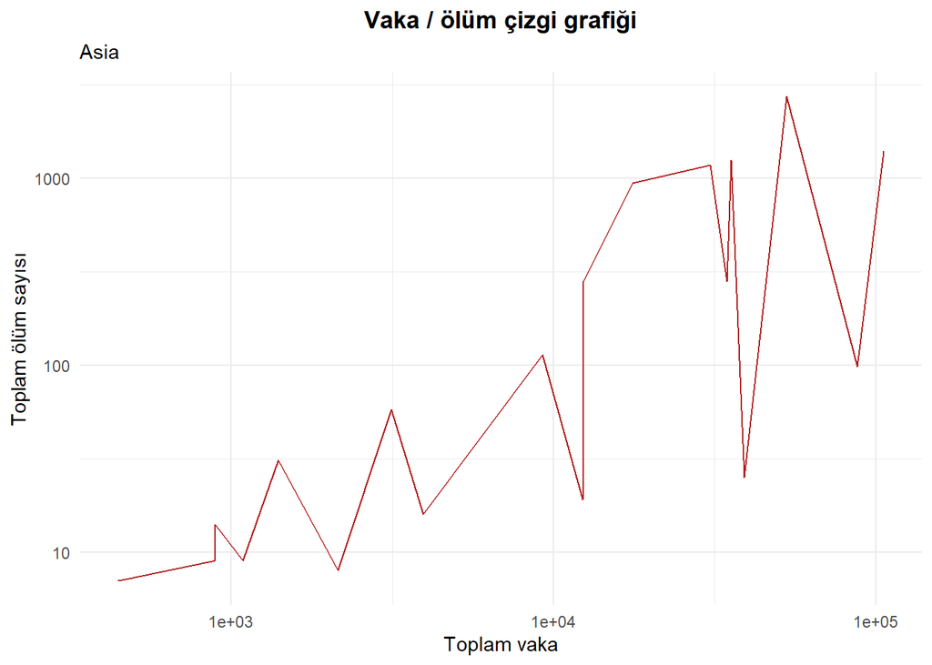

```r
library(dplyr)
library(ggplot2)
y_corona %>%
  filter(continent %in% "Asia") %>%
  ggplot() +
  aes(x = total_cases, y = total_deaths) +
  geom_line(size = 0.5, colour = "#B22222") +
  scale_x_continuous(trans = "log10") +
  scale_y_continuous(trans = "log10") +
  labs(x = "Toplam vaka",
       y = "Toplam ölüm sayısı", title = "Vaka / ölüm çizgi grafiği", subtitle = "Asia") +
  theme_minimal() +
  theme(plot.title = element_text(face = "bold", hjust = 0.5))
```

*Eveet şimdi geldik Asyanın vaka sayısına göre olan ölüm sayısının çizgi grafiğine. Bu kısımda çeşitli iniş çıkışlar olsa da haticeye değil neticeye baktığımızda söyleyebiliriz ki toplam vaka sayısı arttıkça toplam ölüm sayısı da artmış, saygılar.*

**Avrupa’nın toplam vaka / toplam ölüm çizgi grafiği:**

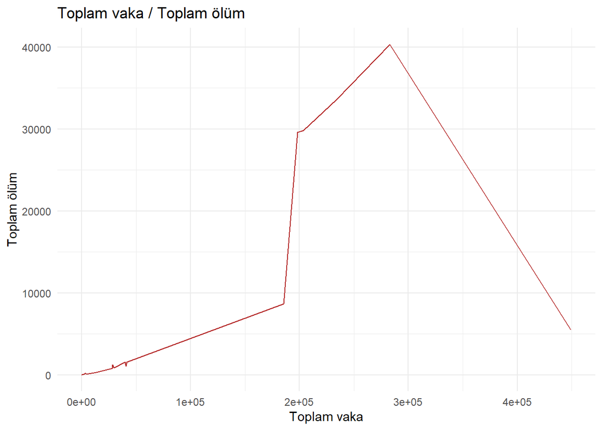

```r
library(dplyr)
library(ggplot2)
y_corona %>%
 filter(continent %in% "Europe") %>%
 ggplot() +
 aes(x = total_cases, y = total_deaths) +
 geom_line(size = 0.5, colour = "#B22222") +
 labs(x = "Toplam vaka", y = "Toplam ölüm", title = "Toplam vaka / Toplam ölüm ") +
 theme_minimal()
```

*Avrupa’nın grafiğine bakmak bizi bir hayli şaşırttı açıkcası. Pek çok konuda bizi şaşırtan Avrupa bu konuda da şaşırttı. Çizgi grafiğine yorum olarak söyleyebiliriz ki vaka sayısı 200000’e yaklaşırken belli bir ivmede seyreden ölüm sayısı 200000’ten 300000’e aşırı bir hızlanma ile vaka sayısı yaklaşık 280000 iken Avrupa haziran ayındaki en fazla ölüm sayısını görmüş. Bu saatten sonra dönüş yok derken Avrupalılar hızlıca toparlanmış dolayısıyla ölüm sayısı hızla düşmüş.*

**Kuzey Amerika’nın toplam vaka / toplam ölüm çizgi grafiği grafiği:**

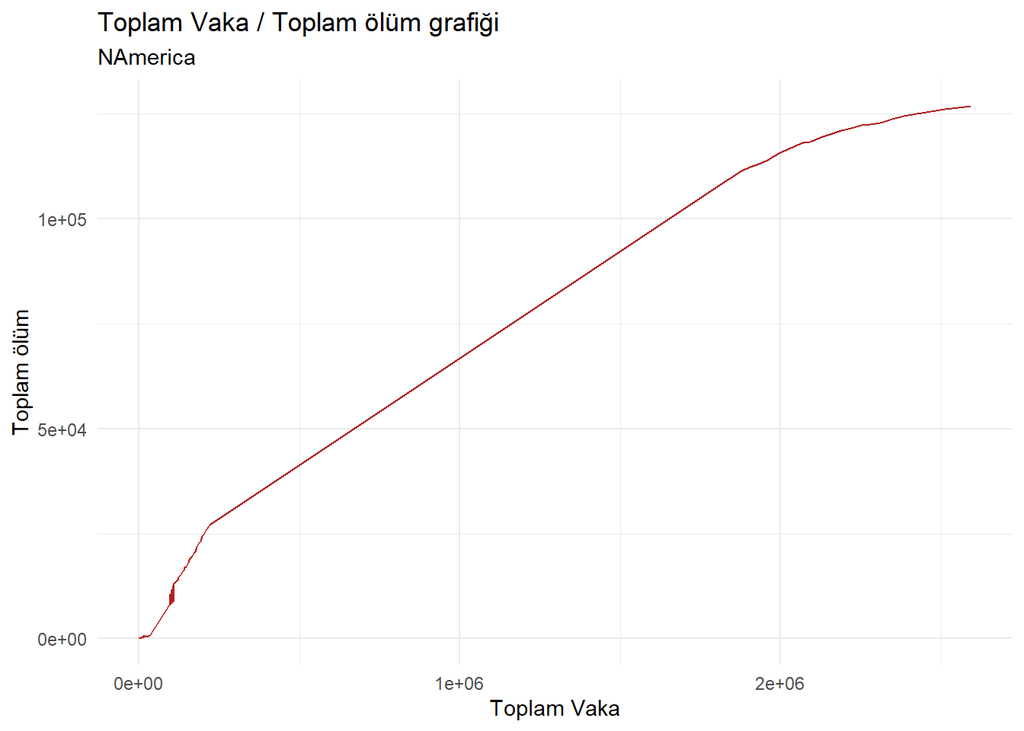

```r
library(ggplot2)
ggplot(North_America) +
 aes(x = total_cases, y = total_deaths) +
 geom_line(size = 0.5, colour = "#B22222") +
 labs(x = "Toplam Vaka", y = "Toplam ölüm", title = "Toplam Vaka / Toplam ölüm grafiği", subtitle = "NAmerica") +
 theme_minimal()
```

*Kuzey Amerika’ya ait olan bu grafiğimizin yorumunda ise klasik olarak toplam vaka arttıkça toplam ölüm de vakaya bağlı olarak artmıştır.*

**Güney Amerika’nın toplam vaka / toplam ölüm çizgi grafiği grafiği:**

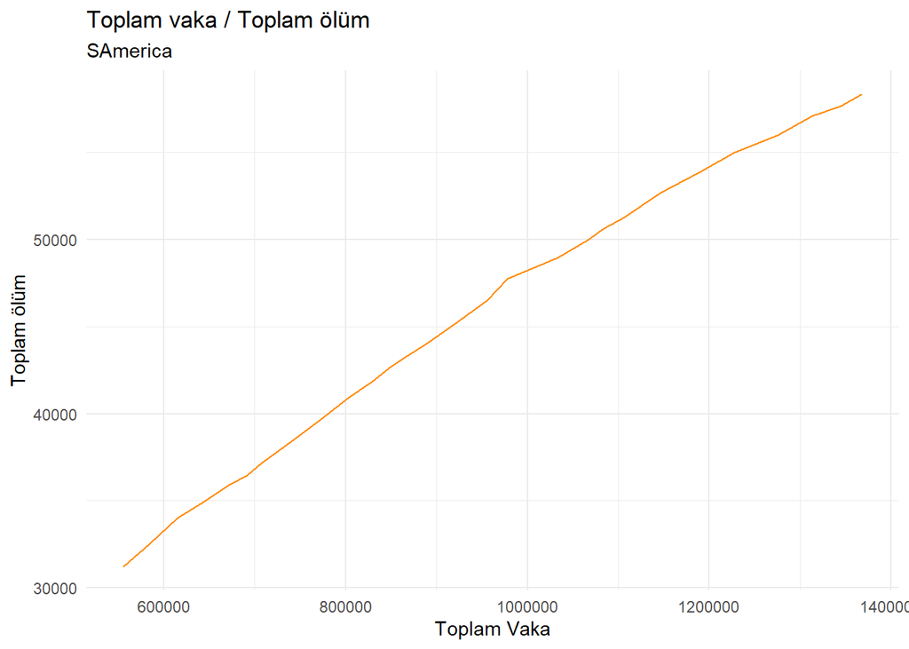

```r
library(dplyr)
library(ggplot2)
South_America %>%
 filter(total_cases >= 284703L & total_cases <= 1368195L) %>%
 ggplot() +
 aes(x = total_cases, y = total_deaths) +
 geom_line(size = 0.5, colour = "#FF8C00") +
 labs(x = "Toplam Vaka", y = "Toplam ölüm", title = "Toplam vaka / Toplam ölüm ", subtitle = "SAmerica") +
 theme_minimal()
```

*Güney Amerika’da Kuzey Amerika’dan çok farklı olmayarak vaka sayısının artışına bağlı olarak ölüm sayıları da artmış.*

**Afrika’nın toplam vaka / toplam ölüm çizgi grafiği grafiği:**

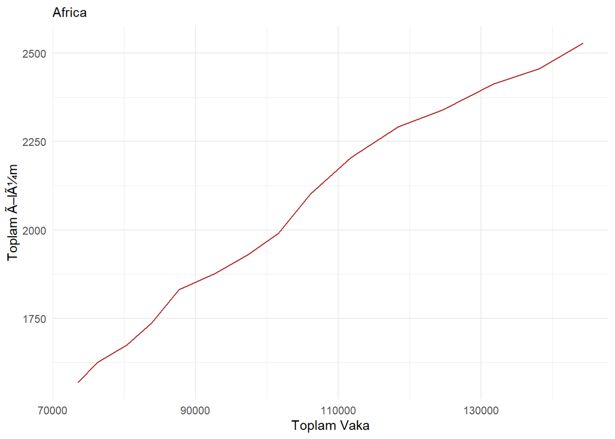

```r
library(dplyr)
library(ggplot2)
africa %>%
 filter(total_cases >= 70217L & total_cases <= 144264L) %>%
 ggplot() +
 aes(x = total_cases, y = total_deaths) +
 geom_line(size = 0.5, colour = "#B22222") +
 labs(x = "Toplam Vaka", y = "Toplam Ã–lÃ¼m", subtitle = "Africa") +
 theme_minimal()
```

*Çoğu grafiğe yaptığımız yoruma Afrika’da dahil olarak sıraya kaynak yaptı. Afrika’nın da ölüm sayıları vaka artışına bağlı olarak artmıştır.*

#### Yoğunluk Grafikleri:

**Asya’nın milyon kişi başına ölüm sayısına ait yoğunluk grafiği:**

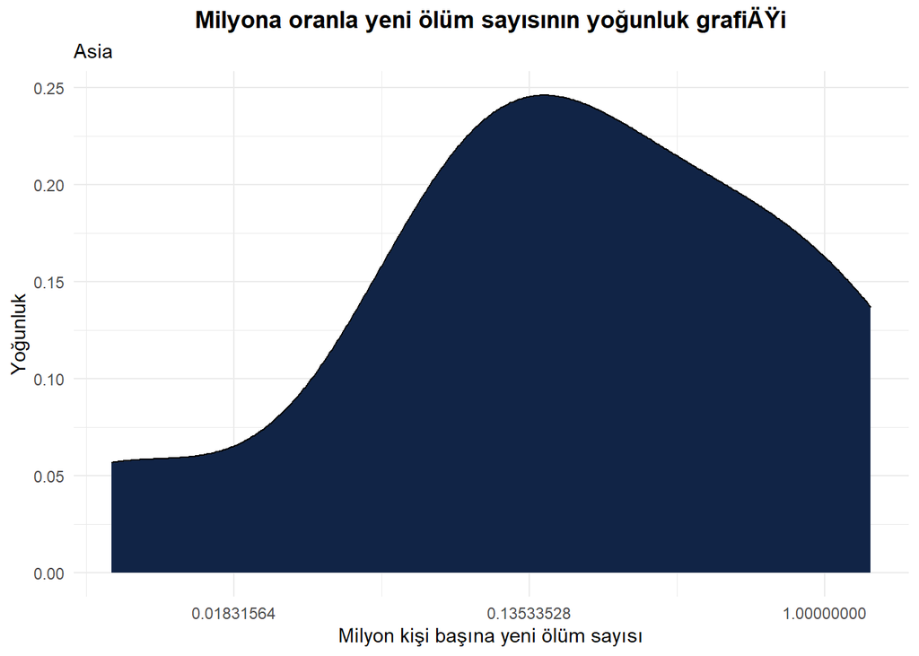

```r
library(dplyr)
library(ggplot2)
y_corona %>%
 filter(continent %in% "Asia") %>%
 ggplot() +
 aes(x = new_deaths_per_million) +
 geom_density(adjust = 1L, fill = "#112446") +
 scale_x_continuous(trans = "log") +
 labs(x = "Milyon kişi başına yeni ölüm sayısı", y = "Yoğunluk", title = "Milyona oranla yeni ölüm sayısının yoğunluk grafiÄŸi",
 subtitle = "Asia") +
 theme_minimal() +
 theme(plot.title = element_text(face = "bold", hjust = 0.5))
```

*Asya’nın yoğunluk grafiğine ilişkin yorumumuzda, en fazla gözlenen sıklığın 0.13533 lik bir ölümn/m.kişi oranıdır.*

**Avrupa’nın milyon kişi başına ölüm sayısına ait yoğunluk grafiği:**

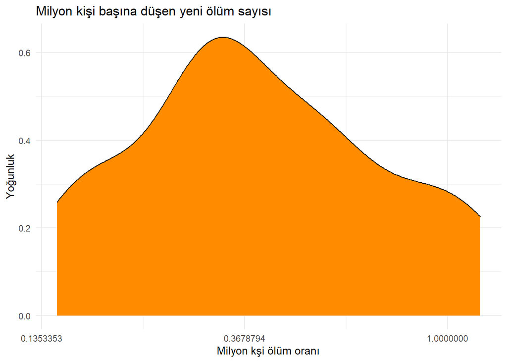

```r
library(dplyr)
library(ggplot2)
y_corona %>%
 filter(continent %in% "Europe") %>%
 ggplot() +
 aes(x = new_deaths_per_million) +
 geom_density(adjust = 1L, fill = "#FF8C00") +
 scale_x_continuous(trans = "log") +
 labs(x = "Milyon kşi ölüm oranı", y = "Yoğunluk", title = "Milyon kişi başına düşen yeni ölüm sayısı") +
 theme_minimal()
```

*Avrupa’ya ait yoğunluk grafiğinde aslında y tarafını yani yoğunluk değişkeninin tabanını 0.2 gibi bir değerle başlatıp x değişkenimizi de daha da yakınlaştırsaydık görebilirdik ki grağimiz görünüm olarak normal dağılıma yakınsıyor. Gerçi bu şekilde de fena bir grafik değil. Beklenildiği gibi ölüm oranı 1’e ve 0’a yakınsadıkça frekansı azalırken ortalama değer en fazla gözlenmiştir.*

**Kuzey Amerika’nın milyon kişi başına ölüm sayısına ait yoğunluk grafiği:**

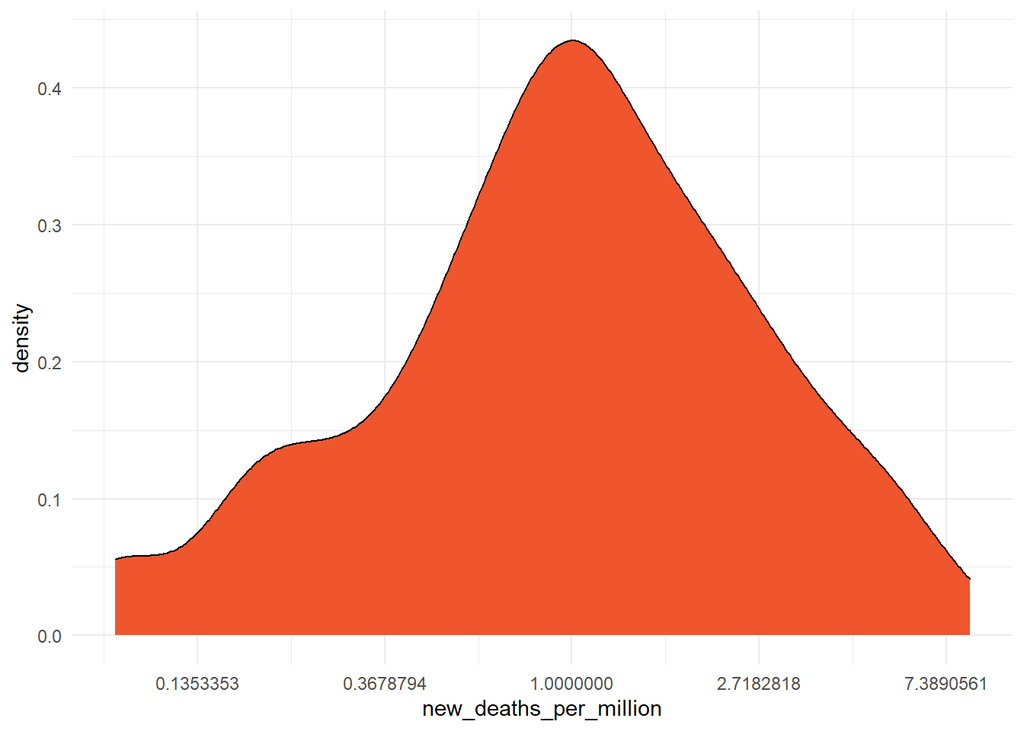

```r
library(ggplot2)
ggplot(North_America) +
 aes(x = new_deaths_per_million) +
 geom_density(adjust = 1L, fill = "#EF562D") +
 scale_x_continuous(trans = "log") +
 theme_minimal()
```

*Kuzey Amerika’nın yoğunluk grafiğine baktığımızda ise ece marka bayram çikolatalarını görmemek mümkün değil. Bu grafikte diğerlerinden farklı olarak, 7’ye ve 0 a yaklaşırken yoğunluğumuz düşüyor. Yoğunluğumuzun peak yaptığı oran konusunda ise 1 diyebiliriz. Oranımızın 7 ye kadar yükseldiğini görmekle de söyleyebiliriz ki milyon kişi başına düşen ölüm sayısı artıyor demek ki tedbirleri elden bırakıp maske ve mesafeye dikkat etmemişler ya da virüslü birisi sürekli insanlara tükürmüş ama bu sonuncu seçenek pek olası değil.*

**Güney Amerika’nın milyon kişi başına ölüm sayısına ait yoğunluk grafiği:**

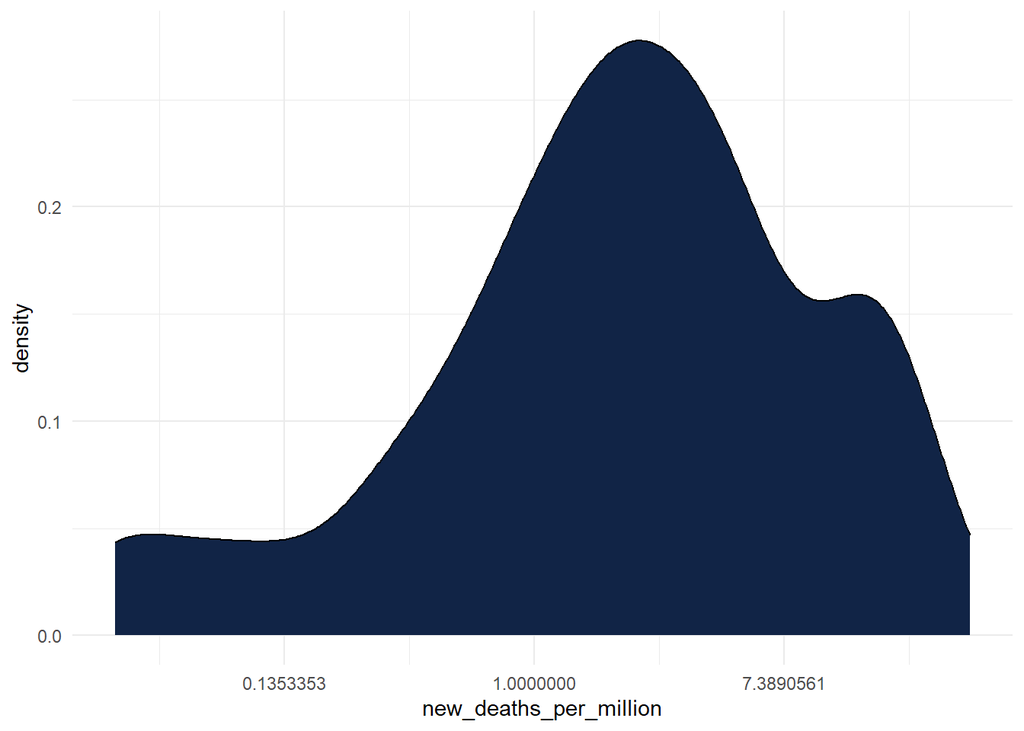

```r
library(ggplot2)
ggplot(South_America) +
 aes(x = new_deaths_per_million) +
 geom_density(adjust = 1L, fill = "#112446") +
 scale_x_continuous(trans = "log") +
 theme_minimal()
```

**Afrika’nın milyon kişi başına ölüm sayısına ait yoğunluk grafiği:**

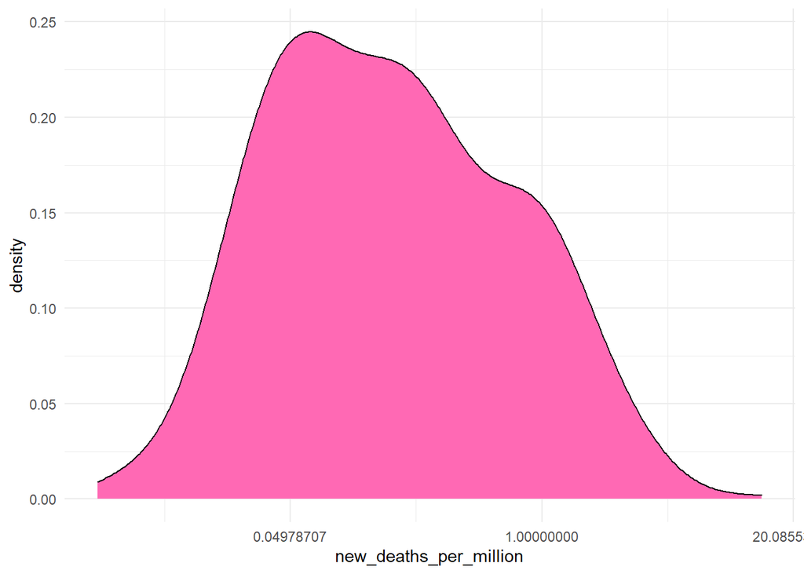

```r
library(ggplot2)
ggplot(africa) +
 aes(x = new_deaths_per_million) +
 geom_density(adjust = 1.4, fill = "#FF69B4") +
 scale_x_continuous(trans = "log") +
 theme_minimal()
```

*Genel manada kıtaların milyon kişi başına düşen ölüm miktarına ilişkin yoğunluk grafiğinde yoğunluğu en fazla hangi noktada toplandığı baz alınarak her kıta için, şu şekilde bir sıralama yapmak bizce doğru olur:* *P<sub>Afrika</sub> < P<sub>Asya</sub> < P<sub>Avrupa</sub> < P<sub>K.Amerika</sub> < P<sub>G.Amerika</sub> <*

## Kaynakça:

[Stack Over Flow](https://stackoverflow.com/questions/60083062/tidyrspread-error-each-row-of-output-must-be-identified-by-a-unique-combina)

[RStudio](https://www.rstudio.com/blog/)

[Book Down](https://bookdown.org/content/2096/)

[dplyr.tidyverse.org](https://dplyr.tidyverse.org/reference/dplyr_tidy_select.html)

[Geeks for Geeks](https://www.geeksforgeeks.org)

[tidyverse.org](https://www.tidyverse.org/)

[Cran.Rproject](https://cran.r-project.org/web/packages/esquisse/vignettes/get-started.html)